# Survival Analysis about algae blooming

Hwang Seong-Yun

2020 11 6

### packages

```r
library(mgcv)
```

```r
library(ggplot2)
library(moonBook)
library(ztable)
library(survival)
library(ggGam)
library(KMsurv)
library(tidyverse)
library(survminer)
```

### 데이터 : 죽산보 유해남조류 관련 (2012년~2020년)

#### 반응변수 : time(당해 1월 1일 기준 발령이 일어날때까지 걸린 시간(일)), status(1 : 조류경보 발령(observed), 0 : 조류경보 일어나지 않음(censored))

#### 설명변수 : temp(수온), pH(수소이온농도), DO(용존산소량), Chl_a(클로로필a), cells(유해남조류세포수), year(년도(strata))

#### 자료출처 : 국립환경과학원 물환경정보시스템 (http://water.nier.go.kr/algae/algaePreMeasure.do?menuIdx=6_2_2)

```r
algae1 <- read.csv("C:/Users/HSY/Desktop/죽산보 남조류 일별 (2012-2020).csv",sep=",",header=T)
algae1$year <- as.character(algae1$year)
summary(algae1)
```

```
##     기준일             조사일               temp              pH
##  Length:543         Length:543         Min.   :  2.30   Min.   :6.100
##  Class :character   Class :character   1st Qu.:  7.80   1st Qu.:7.200
##  Mode  :character   Mode  :character   Median : 17.70   Median :7.700
##                                        Mean   : 16.93   Mean   :7.742
##                                        3rd Qu.: 24.30   3rd Qu.:8.300
##                                        Max.   :122.80   Max.   :9.600
##                                        NA's   :5        NA's   :5
##        DO            Chl_a            cells               time
##  Min.   : 2.70   Min.   :  1.20   Min.   :     0.0   Min.   :  1.0
##  1st Qu.: 7.70   1st Qu.: 21.00   1st Qu.:     0.0   1st Qu.: 73.5
##  Median :10.25   Median : 40.80   Median :     0.0   Median :167.0
##  Mean   :10.60   Mean   : 49.65   Mean   :  4364.7   Mean   :167.8
##  3rd Qu.:13.60   3rd Qu.: 66.30   3rd Qu.:   243.8   3rd Qu.:251.5
##  Max.   :19.80   Max.   :238.50   Max.   :357600.0   Max.   :362.0
##  NA's   :5       NA's   :6        NA's   :5
##      year               status
##  Length:543         Min.   :0.0000
##  Class :character   1st Qu.:0.0000
##  Mode  :character   Median :0.0000
##                     Mean   :0.0663
##                     3rd Qu.:0.0000
##                     Max.   :1.0000
##
```

### Cox Proportional Hazard Model

#### 생존분석 시 유의해야 할 점은 데이터 내에 중도절단(censored)된 경우가 있다는 점이다. 즉, 관심있는 사건이 관찰되지 않고 관측이 끝난 경우를 고려해야 한다.

#### 생존분석에 대한 전체적인 내용은 아래의 사이트를 참조하기 바란다.

#### https://en.wikipedia.org/wiki/Survival_analysis

#### https://ko.wikipedia.org/wiki/%EC%83%9D%EC%A1%B4%EB%B6%84%EC%84%9D

#### http://www.sthda.com/english/wiki/cox-proportional-hazards-model

#### https://bookdown.org/cardiomoon/gam/tab-70.html

#### 우선 층화변수 year를 고려하지 않은 Cox.ph 모형을 적합한다.

```r
algae1_1 <- algae1[,c(3,4,5,6,7)]
algae1_1_scale <- scale(algae1_1)
algae1_2 <- cbind(algae1[,c(1,2,8,9,10)],as.data.frame(algae1_1_scale)) # 모든 설명변수(year 제외) 표준화
attach(algae1_2)
Surv(time,status)
```

```
##   [1]   4+   9+  11+  16+  17+  18+  19+  20+  21+  22+  23+  25+  26+  29+  32+
##  [16]  36+  43+  46+  50+  53+  57+  64+  72+  74+  78+  81+  85+  92+  99+ 102+
##  [31] 106+ 108+ 113+ 116+ 120+ 122+ 127+ 130+ 134+ 137+ 141+ 144+ 149+ 151+ 155+
##  [46] 158+ 162+ 165+ 169+ 172+ 177+ 179+ 183+ 186+ 191+ 201+ 204+ 214+ 219+ 221+
##  [61] 225+ 233+ 241+ 246+ 255+ 263+ 268+ 275+ 282+ 289+ 296+ 302+ 311+ 317+ 323+
##  [76] 333+ 339+ 345+ 351+ 360+   3+   8+  13+  21+  28+  36+  43+  49+  55+  64+
##  [91]  70+  78+  86+  91+  98+ 107+ 113+ 119+ 125+ 133+ 139+ 146+ 154+ 162+ 167+
## [106] 174+ 181+ 188+ 196+ 202+ 209+ 217+ 219+ 224+ 225+ 230+ 233  237+ 239+ 244+
## [121] 252+ 258+ 266+ 273+ 280+ 287+ 294+ 300+ 307+ 315+ 321+ 328+ 336+ 344+ 349+
## [136] 357+   6+  12+  21+  22+  26+  27+  34+  41+  47+  49+  54+  62+  69+  76+
## [151]  82+  90+  97+ 104+ 110+ 117+ 126+ 132+ 139+ 146+ 152+ 160+ 167+ 173+ 181+
## [166] 188+ 195+ 202+ 208+ 216+ 223+ 230+ 237+ 243+ 253+ 258+ 264+ 271+ 279+ 286+
## [181] 292+ 300+ 307+ 314+ 320+ 328+ 334+ 341+ 348+ 356+ 362+   5+  11+  18+  26+
## [196]  33+  39+  46+  53+  61+  63+  68+  70+  75+  81+  89+  96+ 102+ 110+ 117+
## [211] 123+ 130+ 138+ 145+ 152+ 158+ 166+ 173+ 179+ 186+ 194+ 200+ 208+ 214  217+
```

[output cut: 22 more lines]

```r
fit1 <- coxph(Surv(time,status)~temp+pH+DO+Chl_a+cells,ties="efron",data=algae1_2) # Efron 동점처리
summary(fit1)
```

```
## Call:
## coxph(formula = Surv(time, status) ~ temp + pH + DO + Chl_a +
##     cells, data = algae1_2, ties = "efron")
##
##   n= 536, number of events= 36
##    (7 observations deleted due to missingness)
##
##           coef exp(coef) se(coef)      z Pr(>|z|)
## temp   0.29942   1.34907  0.11476  2.609 0.009077 **
## pH     0.68951   1.99274  0.18387  3.750 0.000177 ***
## DO    -1.67732   0.18687  0.32087 -5.227 1.72e-07 ***
## Chl_a  0.09839   1.10339  0.20210  0.487 0.626374
## cells  0.31778   1.37408  0.05274  6.026 1.68e-09 ***
## ---
## Signif. codes:  0 '***' 0.001 '**' 0.01 '*' 0.05 '.' 0.1 ' ' 1
##
##       exp(coef) exp(-coef) lower .95 upper .95
## temp     1.3491     0.7412   1.07734    1.6893
## pH       1.9927     0.5018   1.38977    2.8573
## DO       0.1869     5.3512   0.09964    0.3505
## Chl_a    1.1034     0.9063   0.74251    1.6397
## cells    1.3741     0.7278   1.23914    1.5237
##
## Concordance= 0.872  (se = 0.026 )
## Likelihood ratio test= 90.25  on 5 df,   p=<2e-16
## Wald test            = 90.99  on 5 df,   p=<2e-16
## Score (logrank) test = 237.5  on 5 df,   p=<2e-16
```

#### 적합된 모형에 대한 Likelihood ratio test, Wald test, Score (logrank) test 의 결과를 통해 모형이 유의하다고 판단할 수 있으며, Chl_a를 제외한 나머지 설명변수들 모두 조류경보가 발령되기까지 걸린 시간에 대한 영향력이 유의함을 알 수 있다. 추가로 동점처리를 Breslow나 exact 방법을 이용하여 모형을 적합하면 다음과 같고 그 결과는 동일하다.

```r
fit1_1 <- coxph(Surv(time,status)~temp+pH+DO+Chl_a+cells,ties="breslow",data=algae1_2) # Breslow 동점처리
summary(fit1_1)
```

```
## Call:
## coxph(formula = Surv(time, status) ~ temp + pH + DO + Chl_a +
##     cells, data = algae1_2, ties = "breslow")
##
##   n= 536, number of events= 36
##    (7 observations deleted due to missingness)
##
##           coef exp(coef) se(coef)      z Pr(>|z|)
## temp   0.29920   1.34878  0.11502  2.601 0.009290 **
## pH     0.69060   1.99491  0.18377  3.758 0.000171 ***
## DO    -1.67549   0.18722  0.32108 -5.218 1.81e-07 ***
## Chl_a  0.09815   1.10313  0.20244  0.485 0.627778
## cells  0.31453   1.36961  0.05232  6.012 1.84e-09 ***
## ---
## Signif. codes:  0 '***' 0.001 '**' 0.01 '*' 0.05 '.' 0.1 ' ' 1
##
##       exp(coef) exp(-coef) lower .95 upper .95
## temp     1.3488     0.7414   1.07654    1.6899
## pH       1.9949     0.5013   1.39154    2.8599
## DO       0.1872     5.3414   0.09978    0.3513
## Chl_a    1.1031     0.9065   0.74185    1.6404
## cells    1.3696     0.7301   1.23613    1.5175
##
## Concordance= 0.871  (se = 0.026 )
## Likelihood ratio test= 89.73  on 5 df,   p=<2e-16
## Wald test            = 90.57  on 5 df,   p=<2e-16
## Score (logrank) test = 232.9  on 5 df,   p=<2e-16
```

```r
fit1_2 <- coxph(Surv(time,status)~temp+pH+DO+Chl_a+cells,ties="exact",data=algae1_2) # exact 동점처리
summary(fit1_2)
```

```
## Call:
## coxph(formula = Surv(time, status) ~ temp + pH + DO + Chl_a +
##     cells, data = algae1_2, ties = "exact")
##
##   n= 536, number of events= 36
##    (7 observations deleted due to missingness)
##
##           coef exp(coef) se(coef)      z Pr(>|z|)
## temp   0.30018   1.35011  0.11522  2.605 0.009181 **
## pH     0.69169   1.99709  0.18540  3.731 0.000191 ***
## DO    -1.68380   0.18567  0.32274 -5.217 1.82e-07 ***
## Chl_a  0.10073   1.10598  0.20367  0.495 0.620896
## cells  0.31632   1.37207  0.05308  5.959 2.53e-09 ***
## ---
## Signif. codes:  0 '***' 0.001 '**' 0.01 '*' 0.05 '.' 0.1 ' ' 1
##
##       exp(coef) exp(-coef) lower .95 upper .95
## temp     1.3501     0.7407   1.07718    1.6922
## pH       1.9971     0.5007   1.38863    2.8722
## DO       0.1857     5.3860   0.09863    0.3495
## Chl_a    1.1060     0.9042   0.74197    1.6486
## cells    1.3721     0.7288   1.23650    1.5225
##
## Concordance= 0.872  (se = 0.026 )
## Likelihood ratio test= 90.02  on 5 df,   p=<2e-16
## Wald test            = 90.16  on 5 df,   p=<2e-16
## Score (logrank) test = 233.1  on 5 df,   p=<2e-16
```

#### 모형 fit1에 대해 공변량에 대한 비례성을 검정하면 다음과 같다.

```r
cox.zph(fit1)
```

```
##         chisq df       p
## temp    0.625  1  0.4291
## pH      2.463  1  0.1165
## DO      7.260  1  0.0071
## Chl_a   0.793  1  0.3731
## cells  36.404  1 1.6e-09
## GLOBAL 47.162  5 5.3e-09
```

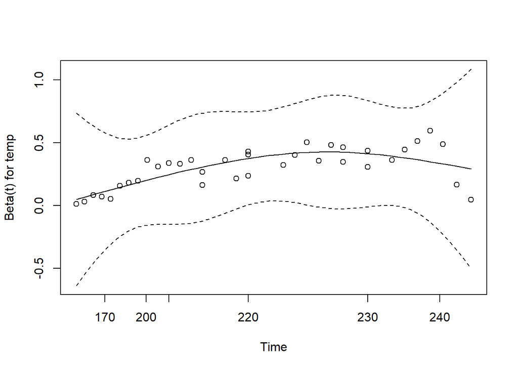

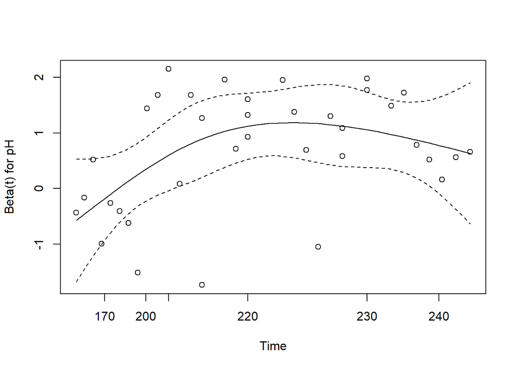

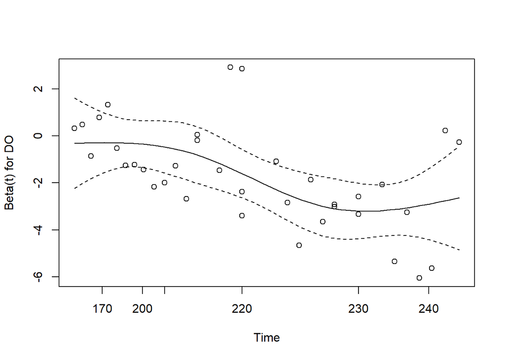

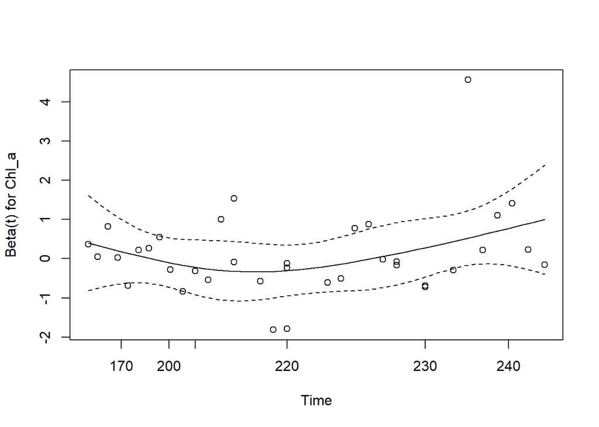

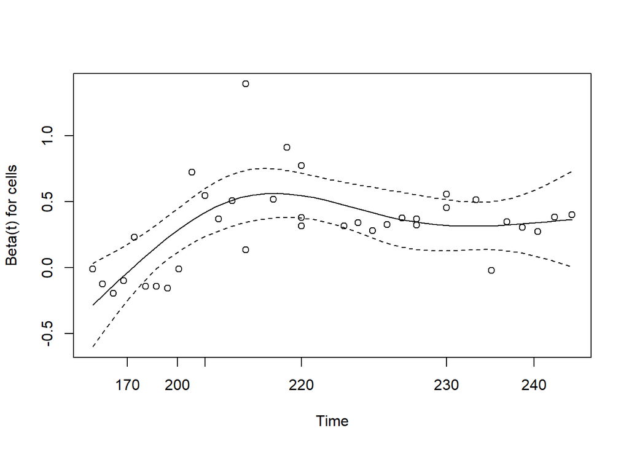

```r
plot(cox.zph(fit1,transform="km")) # Schoenfeld 잔차 산점도
```

#### 비례성 검정 결과와 Schoenfeld 잔차 산점도를 통해 설명변수 temp, pH, Chl_a에 대해서만 비례성을 만족하고 있다. 이에 따라 좀 더 모형을 보강할 필요가 있다.

### Cox proportional hazard model with stratum

#### 층화변수인 year를 포함한 모형을 적합해보고 유의성과 비례성을 검토해본다.

```r
fit2 <- coxph(Surv(time,status)~temp+pH+DO+Chl_a+cells+strata(year),data=algae1_2)
summary(fit2)
```

```
## Call:
## coxph(formula = Surv(time, status) ~ temp + pH + DO + Chl_a +
##     cells + strata(year), data = algae1_2)
##
##   n= 536, number of events= 36
##    (7 observations deleted due to missingness)
##
##           coef exp(coef) se(coef)      z Pr(>|z|)
## temp   2.28375   9.81337  0.89880  2.541 0.011058 *
## pH     1.59747   4.94053  0.45402  3.519 0.000434 ***
## DO    -1.54352   0.21363  0.60779 -2.540 0.011099 *
## Chl_a  0.31663   1.37250  0.35985  0.880 0.378919
## cells  0.07698   1.08002  0.09511  0.809 0.418256
## ---
## Signif. codes:  0 '***' 0.001 '**' 0.01 '*' 0.05 '.' 0.1 ' ' 1
##
##       exp(coef) exp(-coef) lower .95 upper .95
## temp     9.8134     0.1019   1.68560   57.1322
## pH       4.9405     0.2024   2.02914   12.0291
## DO       0.2136     4.6810   0.06491    0.7031
## Chl_a    1.3725     0.7286   0.67796    2.7786
## cells    1.0800     0.9259   0.89635    1.3013
##
## Concordance= 0.889  (se = 0.03 )
## Likelihood ratio test= 101.7  on 5 df,   p=<2e-16
## Wald test            = 42.56  on 5 df,   p=5e-08
## Score (logrank) test = 106.9  on 5 df,   p=<2e-16
```

```r
cox.zph(fit2)
```

```
##         chisq df       p
## temp   24.808  1 6.3e-07
## pH      0.285  1 0.59313
## DO      0.272  1 0.60169
## Chl_a   0.467  1 0.49444
## cells   7.312  1 0.00685
## GLOBAL 25.549  5 0.00011
```

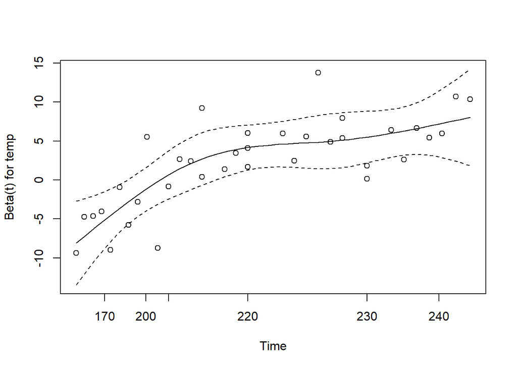

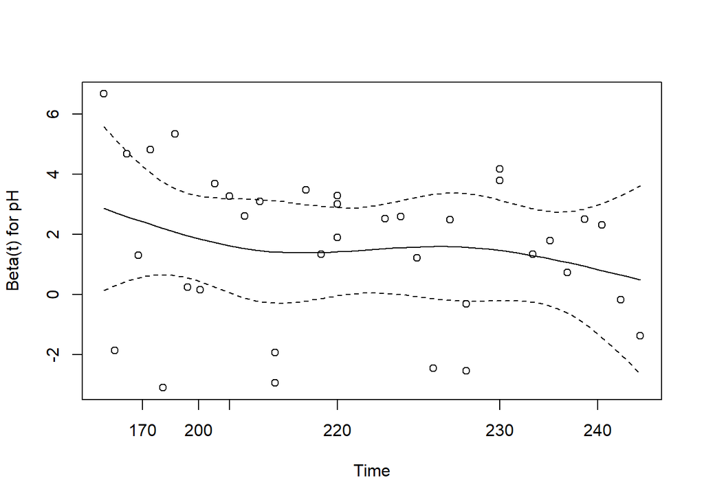

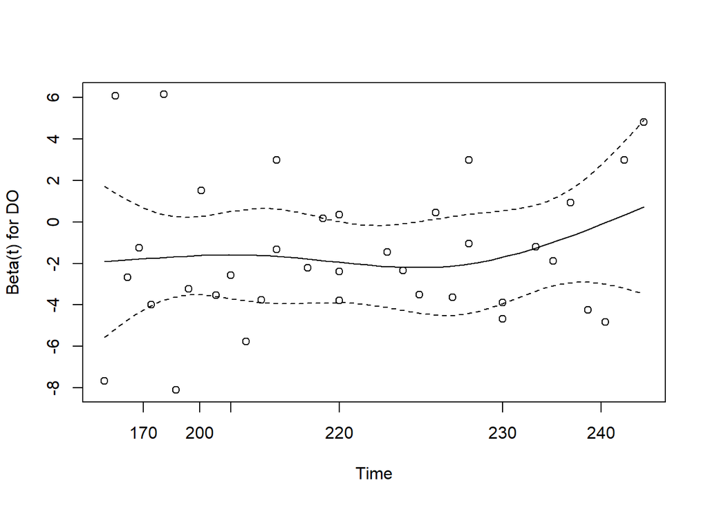

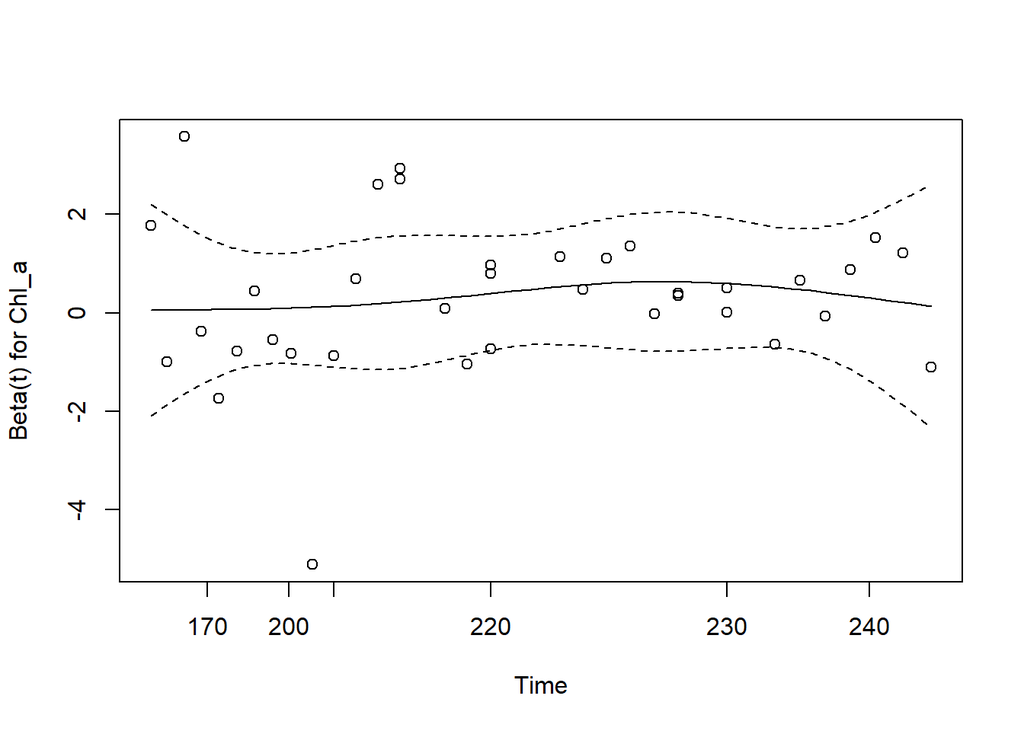

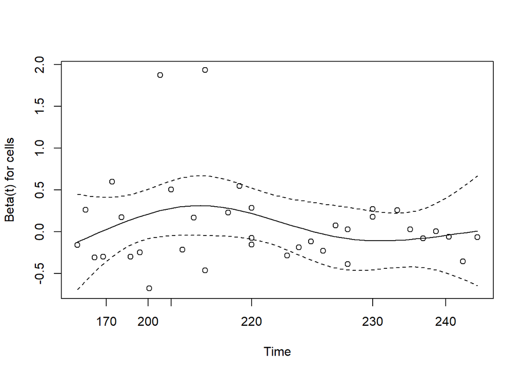

```r
plot(cox.zph(fit2,transform="km"))
```

#### 검정결과, 비례성 검정 부분에서 층화변수 year를 넣었을때의 보정효과가 그렇게 크지는 않은 것으로 판단된다. 이에 따라 층화모형까지는 고려할 필요가 없을 것으로 보인다. 다만 모형 fit1도 비례성에 위배되는 결과를 보임에 따라 각 설명변수에 대한 변환함수를 고려해볼 수 있겠다.

#### 그전에, 단계적 모형 선택(stepwise model selection)을 통해 AIC 기준을 토대로 어떠한 변수가 선택되는지 확인해보자.

```r
library(MASS)
ro.step <- stepAIC(fit1)
```

```
## Start:  AIC=299.33
## Surv(time, status) ~ temp + pH + DO + Chl_a + cells
##
##         Df    AIC
## - Chl_a  1 297.58
## <none>     299.33
## - temp   1 300.79
## - pH     1 312.08
## - cells  1 322.30
## - DO     1 328.79
##
## Step:  AIC=297.58
## Surv(time, status) ~ temp + pH + DO + cells
##
##         Df    AIC
## <none>     297.58
## - temp   1 299.21
## - pH     1 312.60
## - cells  1 320.98
## - DO     1 332.87
```

```r
ro.step
```

```
## Call:
## coxph(formula = Surv(time, status) ~ temp + pH + DO + cells,
##     data = algae1_2, ties = "efron")
##
##           coef exp(coef) se(coef)      z        p
## temp   0.29967   1.34941  0.11252  2.663  0.00774
## pH     0.71892   2.05222  0.17585  4.088 4.35e-05
## DO    -1.61480   0.19893  0.29009 -5.567 2.60e-08
## cells  0.32467   1.38357  0.05177  6.271 3.59e-10
##
## Likelihood ratio test=90.38  on 4 df, p=< 2.2e-16
## n= 537, number of events= 36
##    (6 observations deleted due to missingness)
```

```r
extractAIC(ro.step)
```

```
## [1]   4.0000 297.5819
```

#### 분석결과, Chl_a를 제외한 나머지 설명변수들이 유의수준 0.05에서 유의함을 알 수 있다.

### Generalized Additive Cox Proportional Hazard Model

#### 이제 각 설명변수에 대한 비선형성을 고려한 모형을 적합해보도록 하겠다. 이 모형은 Cox.ph 모형에 일반화가법모형(GAM)을 결합시킨 모형이다.

```r
fit3 <- gam(time ~ s(temp)+s(pH)+s(DO)+s(Chl_a)+s(cells), weights=status, family=cox.ph, data=algae1_2, method="REML") # 중도절단관련 변수는 weights 에 추가
summary(fit3)
```

```
##
## Family: Cox PH
## Link function: identity
##
## Formula:
## time ~ s(temp) + s(pH) + s(DO) + s(Chl_a) + s(cells)
##
## Approximate significance of smooth terms:
##            edf Ref.df Chi.sq  p-value
## s(temp)  3.357  3.866  8.071  0.07760 .
## s(pH)    1.000  1.000  1.247  0.26426
## s(DO)    3.673  4.248 24.789 8.59e-05 ***
## s(Chl_a) 1.000  1.000  6.688  0.00971 **
## s(cells) 8.169  8.679 38.507 5.29e-06 ***
## ---
## Signif. codes:  0 '***' 0.001 '**' 0.01 '*' 0.05 '.' 0.1 ' ' 1
##
## Deviance explained = 84.8%
## -REML = 106.75  Scale est. = 1         n = 536
```

```r
ggGam(fit3)
```

```
##  chr "ggGam(model = fit3)"
## List of 1
##  $ model: chr "fit3"
```

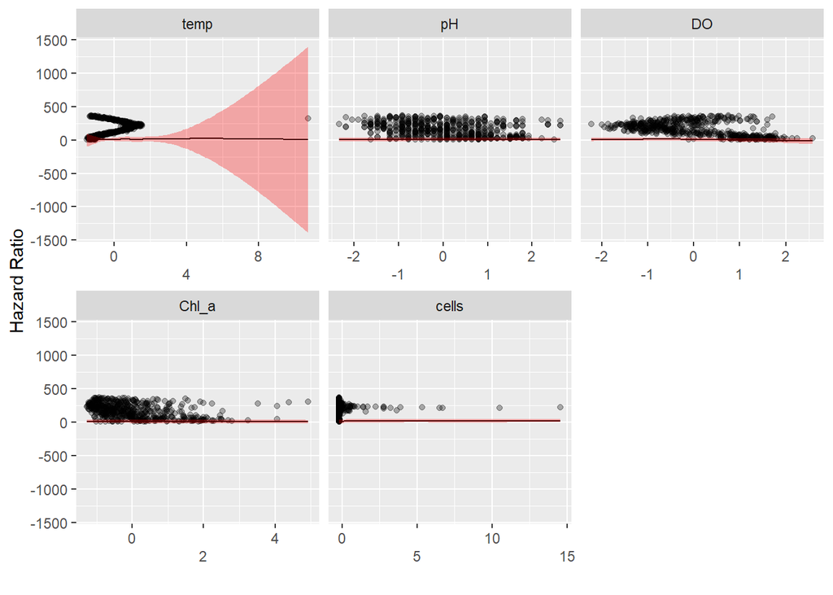

#### 분석결과, Deviance explained 를 통해 적합된 모형이 전체 데이터의 약 84.8% 를 설명하고 있음을 알 수 있다. 그리고 설명변수 temp와 pH에 대해 유의하지 않다는 결과에 따라 순차적으로 유의하지 않은 변수를 제외한 모형을 적합해볼 필요가 있겠다.

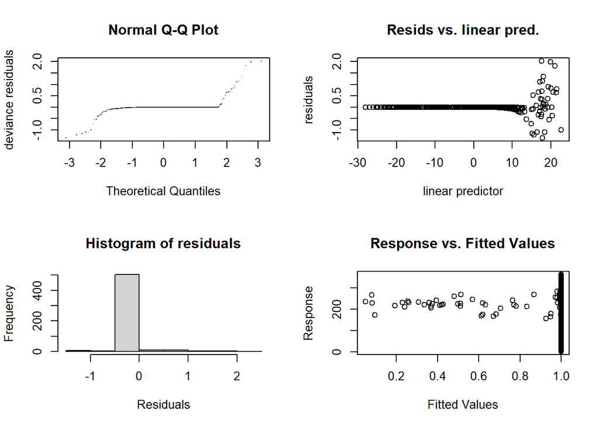

```
##
## Method: REML   Optimizer: outer newton
## full convergence after 14 iterations.
## Gradient range [-0.0003261507,0.0002318681]
## (score 106.7495 & scale 1).
## Hessian positive definite, eigenvalue range [1.760127e-05,30.78495].
## Model rank =  45 / 45
##
## Basis dimension (k) checking results. Low p-value (k-index<1) may
## indicate that k is too low, especially if edf is close to k'.
##
##            k'  edf k-index p-value
## s(temp)  9.00 3.36    1.02    0.69
## s(pH)    9.00 1.00    0.99    0.31
## s(DO)    9.00 3.67    1.09    0.99
## s(Chl_a) 9.00 1.00    0.95    0.10
## s(cells) 9.00 8.17    0.99    0.34
```

```r
par(mfrow=c(2,2))
gam.check(fit3)
```

```r
par(mfrow=c(1,1))
```

#### 전체적으로 봤을 때 각 설명변수들에 대한 차수(기저함수의 개수)는 적절하게 결정된 것으로 보인다. 하지만 잔차에 대한 그래프에서 약간의 가정위반요소가 드러나고 있으므로 유의하지 않은 변수를 제외한 모형을 적합시켜 보겠다.

```r
fit3_1 <- gam(time ~ s(temp)+s(DO)+s(Chl_a)+s(cells), weights=status, family=cox.ph, data=algae1_2, method="REML") # pH 제외
summary(fit3_1)
```

```
##
## Family: Cox PH
## Link function: identity
##
## Formula:
## time ~ s(temp) + s(DO) + s(Chl_a) + s(cells)
##
## Approximate significance of smooth terms:
##            edf Ref.df Chi.sq  p-value
## s(temp)  3.291  3.782  7.081   0.1090
## s(DO)    3.729  4.290 25.065 8.30e-05 ***
## s(Chl_a) 1.000  1.000  5.481   0.0193 *
## s(cells) 8.145  8.656 40.462 9.07e-06 ***
## ---
## Signif. codes:  0 '***' 0.001 '**' 0.01 '*' 0.05 '.' 0.1 ' ' 1
##
## Deviance explained =   85%
## -REML = 107.36  Scale est. = 1         n = 536
```

```r
ggGam(fit3_1)
```

```
##  chr "ggGam(model = fit3_1)"
## List of 1
##  $ model: chr "fit3_1"
```

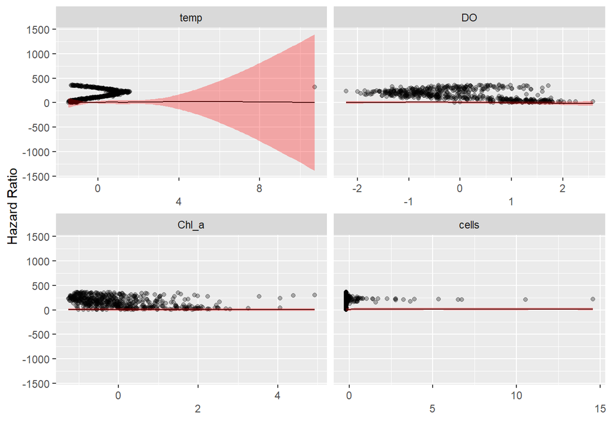

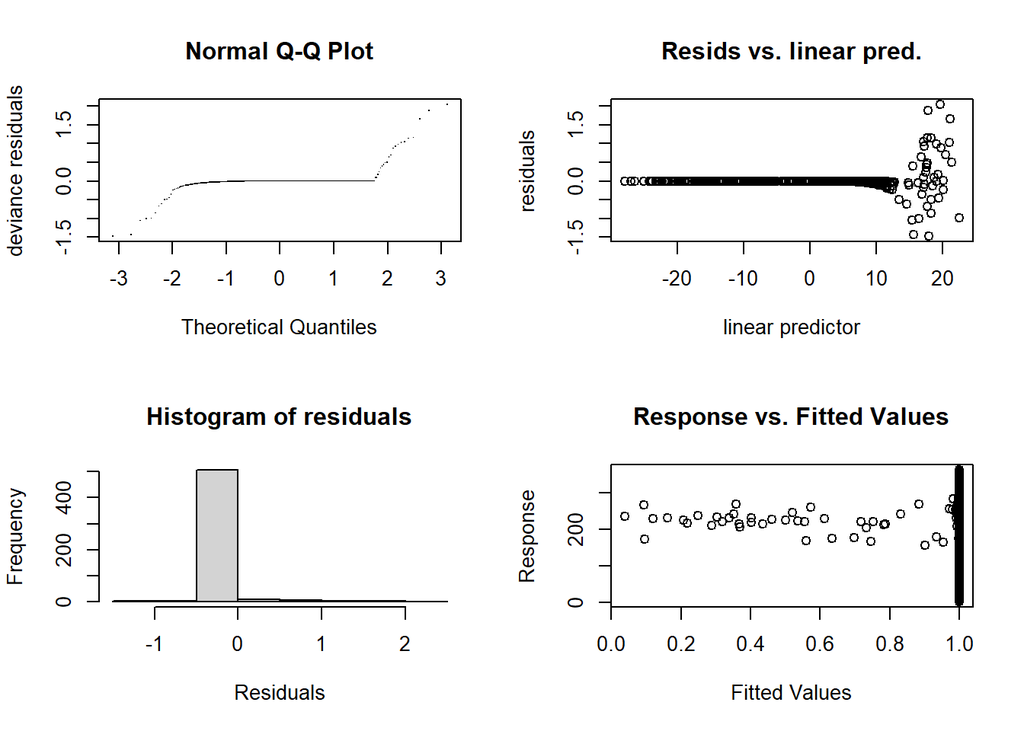

```
##
## Method: REML   Optimizer: outer newton
## full convergence after 11 iterations.
## Gradient range [-0.0005084256,0.0002966068]
## (score 107.3627 & scale 1).
## Hessian positive definite, eigenvalue range [5.191494e-05,35.44685].
## Model rank =  36 / 36
##
## Basis dimension (k) checking results. Low p-value (k-index<1) may
## indicate that k is too low, especially if edf is close to k'.
##
##            k'  edf k-index p-value
## s(temp)  9.00 3.29    1.01    0.52
## s(DO)    9.00 3.73    1.11    0.98
## s(Chl_a) 9.00 1.00    0.94    0.10
## s(cells) 9.00 8.14    0.91    0.04 *
## ---
## Signif. codes:  0 '***' 0.001 '**' 0.01 '*' 0.05 '.' 0.1 ' ' 1
```

```r
par(mfrow=c(2,2))
gam.check(fit3_1)
```

```r
par(mfrow=c(1,1))
fit3_2 <- gam(time ~ s(DO)+s(Chl_a)+s(cells), weights=status, family=cox.ph, data=algae1_2, method="REML") # pH, temp 제외
summary(fit3_2)
```

```
##
## Family: Cox PH
## Link function: identity
##
## Formula:
## time ~ s(DO) + s(Chl_a) + s(cells)
##
## Approximate significance of smooth terms:
##            edf Ref.df Chi.sq  p-value
## s(DO)    3.891  4.480 24.626 0.000124 ***
## s(Chl_a) 1.000  1.000  7.312 0.006855 **
## s(cells) 8.141  8.691 49.057  < 2e-16 ***
## ---
## Signif. codes:  0 '***' 0.001 '**' 0.01 '*' 0.05 '.' 0.1 ' ' 1
##
## Deviance explained = 82.3%
## -REML = 109.92  Scale est. = 1         n = 536
```

```r
ggGam(fit3_2)
```

```
##  chr "ggGam(model = fit3_2)"
## List of 1
##  $ model: chr "fit3_2"
```

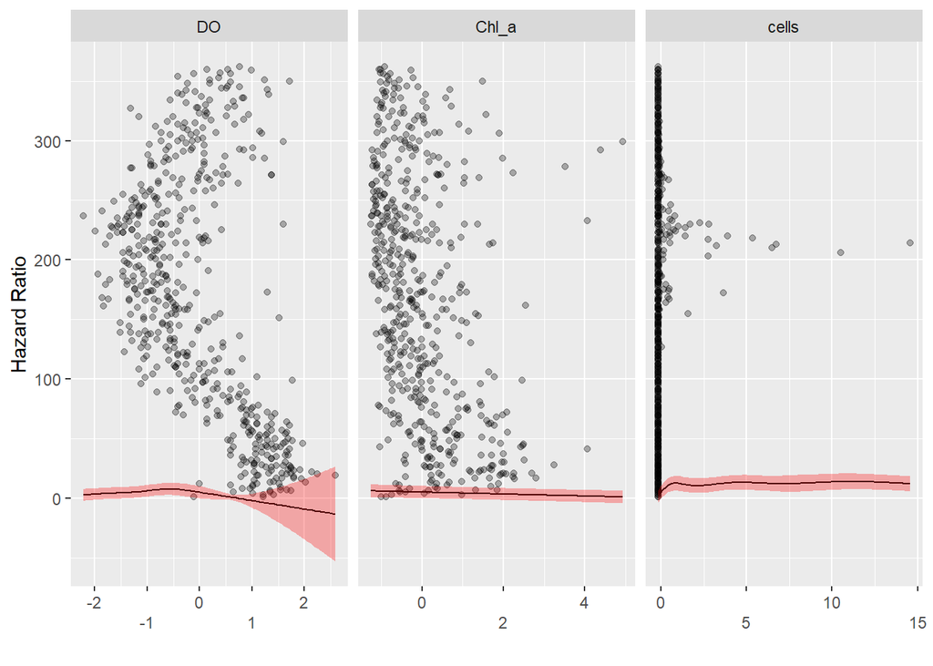

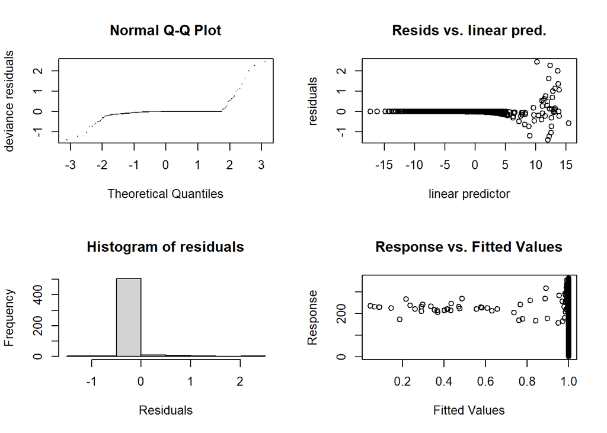

```
##
## Method: REML   Optimizer: outer newton
## full convergence after 10 iterations.
## Gradient range [-3.677581e-05,8.351638e-07]
## (score 109.9171 & scale 1).
## Hessian positive definite, eigenvalue range [3.677383e-05,1.978795].
## Model rank =  27 / 27
##
## Basis dimension (k) checking results. Low p-value (k-index<1) may
## indicate that k is too low, especially if edf is close to k'.
##
##            k'  edf k-index p-value
## s(DO)    9.00 3.89    1.15   1.000
## s(Chl_a) 9.00 1.00    0.95   0.110
## s(cells) 9.00 8.14    0.84   0.005 **
## ---
## Signif. codes:  0 '***' 0.001 '**' 0.01 '*' 0.05 '.' 0.1 ' ' 1
```

```r
par(mfrow=c(2,2))
gam.check(fit3_2)
```

```r
par(mfrow=c(1,1))
concurvity(fit3_2) # 공선성 확인
```

```
##              s(DO)  s(Chl_a)   s(cells)
## worst    0.5208243 0.4913214 0.20937953
## observed 0.4442905 0.4344183 0.16474361
## estimate 0.4385421 0.2600856 0.06134077
```

#### 결과적으로 유의하지 않은 변수를 제거하게 되면 변수 cells에 대한 기저함수가 부족한 모형이 나오는 것으로 보여진다. 하지만 남아있는 모든 설명변수의 영향력이 조류경보가 발령되기까지 걸린 시간에 대해 유의하며 공선성 문제도 심하지 않기 때문에 모형적합은 이 정도로 갈음하도록 한다. 다만, 중요한 수질항목인 BOD, COD, SS, T-N, T-P, TOC 등에 대한 자료가 대국민공개되지 않은 상태이기 때문에 분석에 한계가 있었다.